## Curso de R no IPÊ

### Script do dia 4.2: PCA

*Marcos V. C. Vital e participantes da turma de 2014*

Para mais material, acesse http://marcosvital.wordpress.com/

Este documento é a 2a parte do quarto de uma série que nasceu durante as atividades do “Curso de introdução ao uso do software R e suas aplicações estatísticas nas ciências biológicas”, realizado no IPÊ em dezembro de 2014.

Nesta parte do guia nós vamos realizar uma análise de componentes principais, e vamos explorar seus resultados utlizando-os de várias maneiras.

Como sempre, todo o documento foi criado utilizando o software R, o programa RStudio e a linguagem Markdown. Para saber mais, acesse:

http://www.r-project.org/

http://www.rstudio.com

http://rmarkdown.rstudio.com/

**Antes de começar, carregue os dados necessários:**

```r
setwd("C:/R/Curso IPÊ")
dados<-read.table("insetos.txt", h=T, row.names=1)
attach(dados)

#Aqui um summary vai ser muito carregado, então vou usar um str:
str(dados)
```

```
## 'data.frame':    30 obs. of  40 variables:
##  $ Ambiente   : Factor w/ 2 levels "Mata_Primária",..: 1 1 1 1 1 1 1 1 1 1 ...
##  $ Gado       : Factor w/ 2 levels "Ausente","Presente": 2 1 2 2 2 1 1 1 2 2 ...
##  $ Temperatura: num  21.8 21.3 23.8 23.2 21.5 21.7 20.3 19.7 24.7 20.2 ...
##  $ Cobertura  : int  73 62 57 49 59 78 64 74 48 75 ...
##  $ Luz        : num  53.5 61 71.5 69.5 61.5 53 58 56 71 60.5 ...
##  $ Flores     : int  14 28 17 29 15 24 21 29 20 5 ...
##  $ sp.1       : int  4 5 1 3 5 1 1 0 6 3 ...
##  $ sp.2       : int  0 0 0 0 0 0 3 1 4 0 ...
##  $ sp.3       : int  7 3 2 6 7 2 2 1 8 3 ...
##  $ sp.4       : int  2 7 0 4 2 4 5 3 3 1 ...
##  $ sp.5       : int  0 2 2 1 1 0 3 4 0 0 ...
##  $ sp.6       : int  0 5 2 14 4 3 3 9 8 0 ...
##  $ sp.7       : int  3 2 3 2 1 4 3 2 1 3 ...
##  $ sp.8       : int  2 4 3 5 2 3 0 0 1 0 ...
```

[output cut: 26 more lines]

#### A tal da PCA

Existem diversas funções diferentes no R para calcular uma PCA. Aqui nós vamos usar a função `rda` do pacote `vegan`.

Não há muito mistério: basta executar a função `rda` com o argumento `scale=T`, que faz com que os dados sejam padronizados (uma característica da PCA). Depois, é só chamar o `summary`. Note que o resultado será um pouco longo, ok?

Aí está:

```r
dados.amb<-dados[,3:6]

library(vegan)
resultado.pca<-rda(dados.amb, scale=T)

summary(resultado.pca)
```

```
##
## Call:
## rda(X = dados.amb, scale = T)
##
## Partitioning of correlations:
##               Inertia Proportion
## Total               4          1
## Unconstrained       4          1
##
## Eigenvalues, and their contribution to the correlations
##
## Importance of components:
##                          PC1    PC2     PC3     PC4
## Eigenvalue            2.9765 0.8225 0.15353 0.04753
## Proportion Explained  0.7441 0.2056 0.03838 0.01188
## Cumulative Proportion 0.7441 0.9497 0.98812 1.00000
##
## Scaling 2 for species and site scores
## * Species are scaled proportional to eigenvalues
## * Sites are unscaled: weighted dispersion equal on all dimensions
## * General scaling constant of scores:  3.281818
##
##
## Species scores
##
##                 PC1     PC2       PC3       PC4
## Temperatura  1.5353 -0.2536 -0.516797  0.062751
## Cobertura   -1.5698  0.2432 -0.348431 -0.218239
## Luz          1.5912 -0.2436  0.157733 -0.276448
## Flores       0.8129  1.4254 -0.005553  0.001159
##
##
## Site scores (weighted sums of species scores)
##
##             PC1       PC2      PC3      PC4
## área1  -0.84248 -0.328739 -0.70072  0.78732
## área2  -0.43311  0.333202  0.39672  0.20386
## área3  -0.10240 -0.554527  0.23828 -1.37674
## área4   0.03636  0.130896  0.80606 -0.06254
## área5  -0.49144 -0.460239  0.53132  0.44512
```

[output cut: 10 more lines]

```
## área16  0.04581 -0.644038 -0.66399  0.43237
## área17 -0.52146  0.255348 -0.04659 -0.68786
## área18  0.91741 -0.628082  0.34388  0.24362
## área19 -0.01556  1.303795  0.37912  0.15126
## área20  0.98503  0.029162 -0.77138 -0.18492
## área21  0.81241 -0.443408 -0.40845 -0.35618
## área22  0.63011  0.488145 -0.07909  0.54670
## área23  0.12729  1.033580  0.96023  0.35001
## área24  1.07618  0.234964  0.04026 -0.37270
## área25  0.26441 -0.004436 -0.29826  1.13692
## área26  0.51127  0.426610 -0.64239  0.39092
## área27  0.29284  0.616231 -0.27960  0.36667
## área28  0.46060  0.777148 -0.03278 -1.05485
## área29  0.48418  0.256979  0.61396 -0.68838
## área30  0.76358 -0.669661 -0.22528  0.06431
```

**Plotando de maneira rápida**

Não tem mistério aqui, vamos usar a função `biplot`:

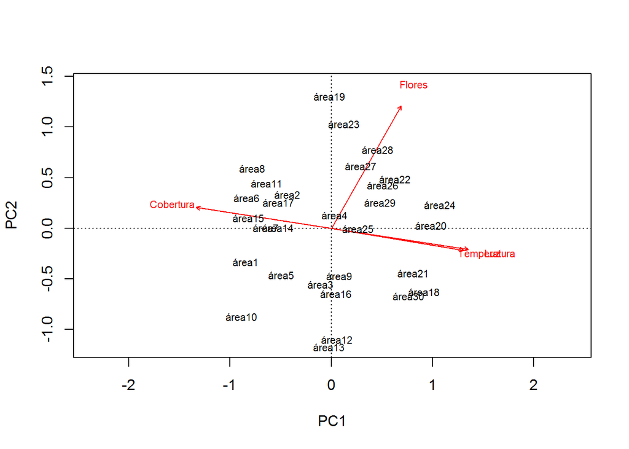

```r
biplot(resultado.pca)
```

Se quiser plotar outros componentes, você pode usar o argumento `choices`. Experimente, por exemplo:

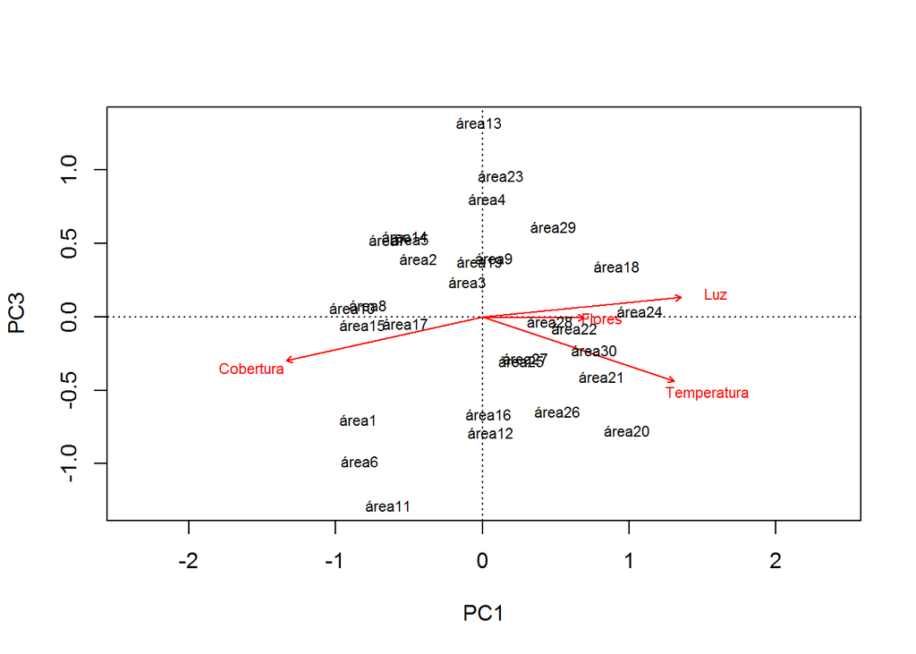

```r
biplot(resultado.pca, choices=c(1,3))  #Plotando os componentes 1 e 3
```

**Incluindo uma variável categórica no grpafico:**

Podemos delimitar os pontos de mata primária e de mata secundária no nosso gráfico assim:

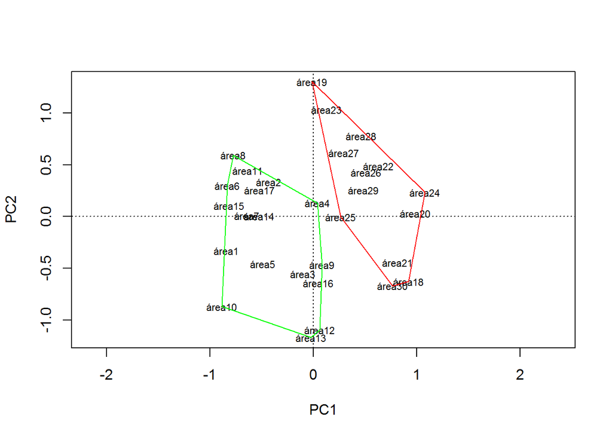

```r
biplot(resultado.pca, display="sites")

ordihull(resultado.pca, group=Ambiente,
show="Mata_Primária", col="green")

ordihull(resultado.pca, group=Ambiente,
show="Mata_Secundária", col="red")
```

Os detalhes:

- usamos o argumento `display="sites"` para mostrar apenas os locais de coleta, sem as variáveis;
- usamos a função `ordihull` para criar polígonos;

Se quiser, confira também o mesmo procedimento acima com a função `ordiellipse`.

#### Brincando com os resultados da PCA

DE novo, vamos explorar os dados sem muito compromisso, apenas para ver como podemos lidar com este tipo de análise no R.

**Extraindo os valores dos componentes principais**

Esta é uma etapa essencial, se quisermos usar os resultados da PCA em outras análises. É bem simples:

```r
pc1<-resultado.pca$CA$u[,1]
pc2<-resultado.pca$CA$u[,2]
```

**Exemplinho rápido com teste T:**

```r
t.test(pc1~Ambiente, var.equal=T)
```

```
##
##  Two Sample t-test
##
## data:  pc1 by Ambiente
## t = -7.599, df = 28, p-value = 2.811e-08
## alternative hypothesis: true difference in means is not equal to 0
## 95 percent confidence interval:
##  -0.3838587 -0.2208520
## sample estimates:
##   mean in group Mata_Primária mean in group Mata_Secundária
##                    -0.1310207                     0.1713347
```

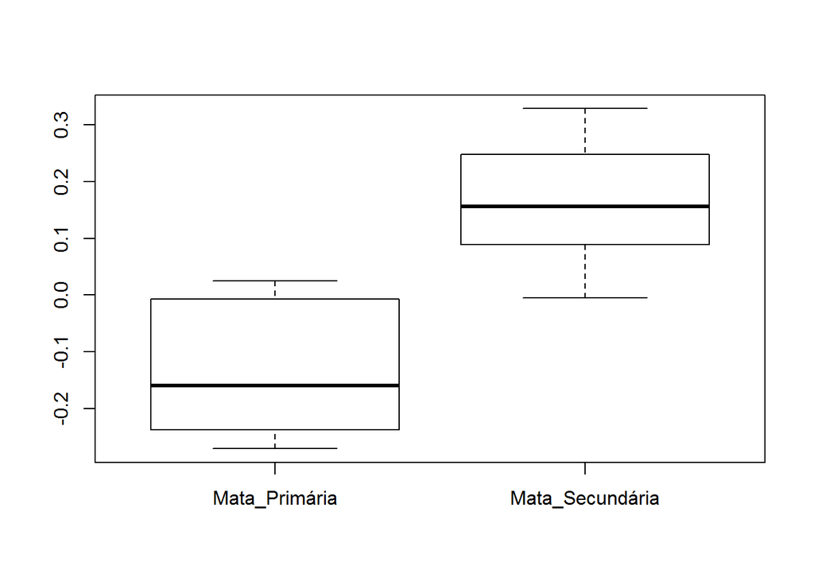

```r
boxplot(pc1~Ambiente)
```

**E exemplinho rápido com regressão:**

```r
abundâncias<-rowSums(dados[,7:40])

modelo<-lm(abundâncias~pc1)
summary(modelo)
```

```
##
## Call:
## lm(formula = abundâncias ~ pc1)
##
## Residuals:
##     Min      1Q  Median      3Q     Max
## -28.485  -9.075   1.509  10.140  44.424
##
## Coefficients:
##             Estimate Std. Error t value Pr(>|t|)
## (Intercept)   60.933      2.931  20.788  < 2e-16 ***
## pc1           75.435     16.055   4.699 6.32e-05 ***
## ---
## Signif. codes:  0 '***' 0.001 '**' 0.01 '*' 0.05 '.' 0.1 ' ' 1
##
## Residual standard error: 16.06 on 28 degrees of freedom
## Multiple R-squared:  0.4409, Adjusted R-squared:  0.4209
## F-statistic: 22.08 on 1 and 28 DF,  p-value: 6.323e-05
```

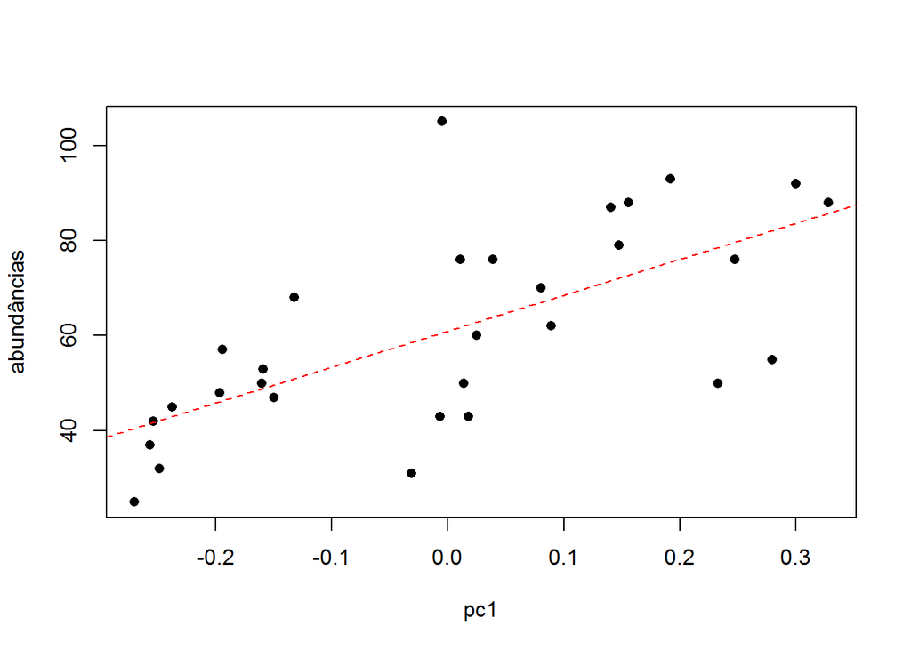

```r
plot(abundâncias~pc1, pch=16)
abline(modelo, lty=2, col="red")
```

Aqui notem que eu usei a função `rowSums` para calcular as abundâncias totais das espécies.

**E é isso aí, dois do dia já foram, ainda falta um. Nos vemos lá!**